# Simulating Forest Fires

#### David Hudson

##### Introduction

- ##### Forest fires are a lethal, destructive disaster that wreak havic in forested areas accross the world. In 2018 alone the United States experienced 52,303 wildfires according to the National Interagency Fire Center. About 8.5 million acres were burned in the 2018 period. In July of 2018 The Mendocino Complex Fire broke out in Northern California and grew to be the largest fire in state history with 459,123 acres burned.
- ##### The extreme heat created by large trees being burned translates to often aggressively moving fires that are difficult to extinguish. Specifically the western United States is continuously effected by these fires due to the arid climate. These wild events often start without warning by the most minute or flames whether it be unattended campfires, downed power lines, or even discarded cigarettes.

##### Outline

- ##### This threat is what make the study of forest fires so important. This simulation below is aimed to look at the behaviors of forest fires. How will a random fire proliferate and what factors causes it to burn itself out? To further simulate the true nature of forest fires burning trees within the simulation will burn for a total of 5 time steps.

### Design

###### We start off by importing a number of packages that will come into use as we progress through development

```python
%matplotlib inline

from pathlib import Path
import matplotlib.pyplot as plt # Ploting
import numpy as np # Used for number manipulation
import pandas as pd # Used to store the date for further analysis
from IPython.display import HTML # Used to convert the animation to video
from matplotlib import animation, rc # Animation
from matplotlib.colors import LinearSegmentedColormap # For dynamic coloring of the visualtion

#had to import ffmpeg to the working folder in order to run simulation
plt.rcParams['animation.ffmpeg_path'] = 'ffmpeg.exe' # needed for parsing the simulation animation


# Settings
rc("animation", html="html5")
```

#### Initialize the system

```python
def init_forest(n, prob_tree, prob_burning):
    """Intializes the forest matrix

    Parameters
    ----------
    n : int
        The integer used to define the dimensions of the forest

    prob_tree : float
        The probability that a tree exists in an individual cell

    prob_burning : float
        The probability that a tree begins on fire
    """

    forest = np.zeros(shape=(n, n), dtype=np.int)

    # We use the prob_tree argument to create a boolean matrix for signify where a tree will be
    tree_cells = np.random.uniform(low=0, high=1, size=(n, n)) < prob_tree
    number_trees = np.prod(forest[tree_cells].shape)

    # We use prob_burning to intialize several trees that start on fire
    # This should be significantly low, < 0.20%
    is_burning = np.random.uniform(low=0, high=1, size=number_trees) < prob_burning
    burning_cells = tree_cells.copy()
    np.place(burning_cells, tree_cells, is_burning)

    forest[tree_cells] = 1
    forest[burning_cells] = 2

    return forest
```

###### The simulation takes place on a numpy matrix, each cell in the matrix has a number that corresponds to the status of that simulated area. In this initial case:

- ###### 0 = Bare Ground
- ###### 1 = Trees
- ###### 2 = Initially Burning Trees

```python
def boundary_condition(forest, condition):
    """Setup ghost cells for boundary condition.

    Parameters
    ----------
    forest : np.array
        The grid of trees

    condition : str, optional
        The boundary condition to use when creating ghost cells.
    """
    if condition == "reflecting":
        extended_forest = np.pad(array=forest, pad_width=(1, 1), mode='edge')
    elif condition == "absorbing":
        extended_forest = np.pad(array=forest, pad_width=(1, 1), mode='constant', constant_values = 25)
    elif condition == "periodic":
        extended_forest = np.pad(array=forest, pad_width=(1, 1), mode='wrap')
    else:
        raise ValueError(
            "{0} is not a valid boundary condition".format(condition))

    return extended_forest
```

###### Because our simulation is limited in forest dimension we are forced to improvise. This function effects the border of the forest matrix with the following rules:

- ###### Reflecting: Reflects the effects this border cell has recieved in the opposite direction.
- ###### Absorbing: Absorbs the effects this border cell has recieved effecting no cells directly.
- ###### Periodic: Allows the matrix to act sphere like in that the effects being felt on the border are rapped around to the opposing border of the matrix.

```python
def get_neighbors(extended_forest, ghost_width=(1, 1)):
    """Returns a matrix of cells that indicating which cells are neighboring a burning tree
    Parameters
    ----------
    extended_forest : np.array
        The forest with borders created in the previous funciton

    ghost_width : np.array
        A two number array with the number of cells prefered for the border width
    """

    m_extended, n_extended = extended_forest.shape
    m, n = (m_extended - ghost_width[0], n_extended - ghost_width[1])


    forest_with_neighbors = np.array(
        [
            np.roll(extended_forest, shift=(0, 1), axis=(1, 0))[
                ghost_width[0] : m, ghost_width[1] : n
            ],
            np.roll(extended_forest, shift=(1, 0), axis=(1, 0))[
                ghost_width[0] : m, ghost_width[1] : n
            ],
            np.roll(extended_forest, shift=(-1, 0), axis=(1, 0))[
                ghost_width[0] : m, ghost_width[1] : n
            ],
            np.roll(extended_forest, shift=(0, -1), axis=(1, 0))[
                ghost_width[0] : m, ghost_width[1] : n
            ],
        ]
    )

    return forest_with_neighbors
```

###### This function makes good use of the np.roll function to return an array of trees that are at risk of cathcing fire

#### The Functionality

```python
def spread(forest, forest_neighbors, prob_immune, prob_lightning, fire_intens):
    """Calculates the probability for a fire to spread to a neighbor tree or not.
    Parameters
    ----------
    forest : np.array
        The previously create forest

    forest_neighbors : np.array
        The array of at risk neighbors created in the previous function

    prob_immune : float
        The probabilty that a tree will not catch fire

    prob_lightning : float
        The probability that lightning will hit a random tree

    fire_intens : list
        A 5 number array of float values corresponding to the intensity of the five phases of a tree burning. Shouldn't be
        less than prob_immune
    """


    # Get number of neighbors per cell and x,y dimensions
    num_neighbors, m, n = forest_neighbors.shape

    # Use copy of forest to help prevent premature updating of cellular states.
    forest_update = forest.copy()

    # Find the tree cells and burning cells
    tree_cells = forest_update == 1
    burning_cells_step1 = forest_update == 2
    burning_cells_step2 = forest_update == 3
    burning_cells_step3 = forest_update == 4
    burning_cells_step4 = forest_update == 5
    burning_cells_step5 = forest_update == 6

    # Compute the probability that a lightning strike causes a fire.
    prob_lightning_fire = prob_lightning * (1 - prob_immune)


    # Boolean condition: which cells have what type of burning neighbor?
    cells_with_burning_neighbors_step1 = np.any(forest_neighbors == 2, axis=0)
    cells_with_burning_neighbors_step2 = np.any(forest_neighbors == 3, axis=0)
    cells_with_burning_neighbors_step3 = np.any(forest_neighbors == 4, axis=0)
    cells_with_burning_neighbors_step4 = np.any(forest_neighbors == 5, axis=0)
    cells_with_burning_neighbors_step5 = np.any(forest_neighbors == 6, axis=0)

    # Boolean condition: Which of the cells with burning neighbors has a tree
    # state
    trees_with_burning_neighbors_step1 = np.logical_and(
        tree_cells, cells_with_burning_neighbors_step1
    )
    trees_with_burning_neighbors_step2 = np.logical_and(
        tree_cells, cells_with_burning_neighbors_step2
    )
    trees_with_burning_neighbors_step3 = np.logical_and(
        tree_cells, cells_with_burning_neighbors_step3
    )
    trees_with_burning_neighbors_step4 = np.logical_and(
        tree_cells, cells_with_burning_neighbors_step4
    )
    trees_with_burning_neighbors_step5 = np.logical_and(
        tree_cells, cells_with_burning_neighbors_step5
    )


    number_trees_with_burning_neighbors_step1 = np.sum(trees_with_burning_neighbors_step1)
    number_trees_with_burning_neighbors_step2 = np.sum(trees_with_burning_neighbors_step2)
    number_trees_with_burning_neighbors_step3 = np.sum(trees_with_burning_neighbors_step3)
    number_trees_with_burning_neighbors_step4 = np.sum(trees_with_burning_neighbors_step4)
    number_trees_with_burning_neighbors_step5 = np.sum(trees_with_burning_neighbors_step5)

    # Generate a random number to determine how the fire spreads:
    # Using the relative fire intensity we can increase and decrease a trees immunity thus making the fire more or less "intense"
    is_burning_step1 = (
        np.random.uniform(low=0, high=1, size=number_trees_with_burning_neighbors_step1)
        >= (prob_immune / fire_intens[0])
    )
    is_burning_step2 = (
        np.random.uniform(low=0, high=1, size=number_trees_with_burning_neighbors_step2)
        >= (prob_immune / fire_intens[1])
    )
    is_burning_step3 = (
        np.random.uniform(low=0, high=1, size=number_trees_with_burning_neighbors_step3)
        >= (prob_immune / fire_intens[2])
    )
    is_burning_step4 = (
        np.random.uniform(low=0, high=1, size=number_trees_with_burning_neighbors_step4)
        >= (prob_immune / fire_intens[3])
    )
    is_burning_step5 = (
        np.random.uniform(low=0, high=1, size=number_trees_with_burning_neighbors_step5)
        >= (prob_immune / fire_intens[4])
    )


    # Create an array and fill it with the False boolean, then use np.place()
    # with trees_with_burning_neighbors to label the sites that will burn
    trees_catching_fire = np.full(fill_value=False, shape=(m, n), dtype=np.bool)
    np.place(trees_catching_fire, trees_with_burning_neighbors_step1, is_burning_step1)
    np.place(trees_catching_fire, trees_with_burning_neighbors_step2, is_burning_step2)
    np.place(trees_catching_fire, trees_with_burning_neighbors_step3, is_burning_step3)
    np.place(trees_catching_fire, trees_with_burning_neighbors_step4, is_burning_step4)
    np.place(trees_catching_fire, trees_with_burning_neighbors_step5, is_burning_step5)



    # Next, we test if lightning strikes and causes a fire.
    # Remove the trees from our list that will already catch fire this round
    tree_cells[trees_catching_fire] = False
    number_remaining_trees = np.sum(tree_cells)

    # Check if each tree cell gets hit by lightning AND starts a fire
    is_burning = (
        np.random.uniform(low=0, high=1, size=number_remaining_trees)
        < prob_lightning_fire
    )
    trees_burned_by_lightning = np.full(fill_value=False, shape=(m, n), dtype=np.bool)

    # Use np.place() to mark the cells with trees burned by lightning for
    # update
    np.place(trees_burned_by_lightning, tree_cells, is_burning)

    # Combine burning trees from spreading and lightning into one list
    new_burning_cells = np.logical_or(trees_catching_fire, trees_burned_by_lightning)

    # Update states
    # Replace trees that burned in the previous round with an empty square
    forest_update[burning_cells_step5] = 0

    # Use combined list of trees to burn during the next time step to update
    # their state:
    forest_update[new_burning_cells] = 2
    forest_update[burning_cells_step1] = 3
    forest_update[burning_cells_step2] = 4
    forest_update[burning_cells_step3] = 5
    forest_update[burning_cells_step4] = 6
    forest_update[burning_cells_step5] = 0

    # Added a third update for those trees that are on round 2 of burning

    return forest_update
```

#### Bring the code together and record the data

```python
def sweep(forest, prob_immune, prob_lightning, nstep, simulation_history, fire_intens, condition):
    """Runs an iteration of the simulation and returns an updated foret
    Parameters
    ----------
    forest : np.array
        The previously created forest

    prob_immune : float
        The probabilty that a tree will not catch fire

    prob_lightning : float
        The probability that lightning will hit a random tree

    nstep : int
        The nth time step that is currently being ran

    simulation_history : np.array
        An array holding the past iterations of the forest simulation

    fire_intens : list
         A 5 number array of float values corresponding to the intensity of the five phases of a tree burning. Shouldn't be
        less than prob_immune

    condition : str
        The boundary condition being used for the simulation
    """

    extended_forest = boundary_condition(forest, condition)
    forest_neighbors = get_neighbors(extended_forest)
    forest_update = spread(forest, forest_neighbors, prob_immune, prob_lightning, fire_intens)
    forest[:, :] = forest_update
    simulation_history.append([nstep, forest_update])
```

```python
def forest_fire_simulation(number_time_steps, n, prob_tree, prob_burning, prob_immune, prob_lightning, fire_intens, condition):
    """Completes the full process of the simulation
    Parameters
    ----------
    number_time_steps : int
        The number of iterations the simulation will run
    prob_tree : float
        The probabilty that a tree will exist

    prob_burning: float
        The probabilty that a tree will start on fire

    prob_immune : float
        The probabilty that a tree will not catch fire

    prob_lightning : float
        The probability that lightning will hit a random tree

    nstep : int
        The nth time step that is currently being ran

    simulation_history : np.array
        An array holding the past iterations of the forest simulation

    fire_intens : list
         A 5 number array of float values corresponding to the intensity of the five phases of a tree burning. Shouldn't be
        less than prob_immune

    condition : str
        The boundary condition being used for the simulation
    """

    forest = init_forest(n, prob_tree, prob_burning)
    simulation_history = [[0, forest.copy()]]

    for nstep in np.arange(1, number_time_steps + 1):
        sweep(forest, prob_immune, prob_lightning, nstep, simulation_history, fire_intens, condition)

    return simulation_history
```

#### Animate

```python
def ca_animation(simulation_history, fig_width=6, fig_height=6, dpi=120):

    # The shape dimensions of the entered data to be used for late
    m, n = simulation_history[0][1].shape

    # Intialize plot
    fig, ax = plt.subplots(figsize=(fig_width, fig_height), dpi=dpi)

    """
    Colors:
        0 = Black (Nothing)
        1 = Green (Tree)
        2-6 = Yellow-Orange-DarkRed
    """
    #The color choice is imperative to interpreting the visualization
    #Using RGBA coloring we can adjust the alpha to show the right about of fading
    colors = ((0.0,0.0,0.0,0.8),
              (0.20,0.60,0.20,0.9),
              (1.0,0.6,0.0,0.90),
              (1.0,0.45,0.0,1.0),
              (1.0,0.3,0.0,1.0),
              (0.90,0.2,0.0,1.0),
              (0.75,0.2,0.0,1.0))
    cmap = LinearSegmentedColormap.from_list(
        "forestfire", colors, N = 7
    )

    #using imshow to bring together the data and colors for visualization
    im = ax.imshow(
        simulation_history[0][1], cmap=cmap, interpolation="nearest", vmin=0, vmax=7
    )

    #set graph boundary limits
    xticks_start, xticks_end = ax.get_xlim()
    yticks_start, yticks_end = ax.get_ylim()

    #Set grid lines and tick marks to differentiate between cells
    ax.xaxis.set_ticks(np.linspace(xticks_start, xticks_end, n + 1), minor=False)
    ax.yaxis.set_ticks(np.linspace(yticks_start, yticks_end, m + 1), minor=False)
    ax.axes.grid(True, linestyle="-", linewidth=0.3, color="white", which="major")

    ax.tick_params(labelbottom=False, labelleft=False, bottom=False, left=False)

    #initiate animation and declare data being used
    def init():
        im.set_array(np.array([[]]))
        return (im,)

    def animate(i):
        forest_i = simulation_history[i][1]
        im.set_array(forest_i)

        return (im,)

    plt.close()

    #use slower intercal at 120 to be able to watch the fire develop
    anim = animation.FuncAnimation(
        fig=fig,
        func=animate,
        frames=len(simulation_history),
        init_func=init,
        interval=120,
        blit=True,
    )

    return anim
```

#### Full Simulation and Output

```python
n = 50
prob_tree = 0.80
prob_burning = 0.0005
prob_immune = 0.25
prob_lightning = 0.00001
number_time_steps = 100
bound_condition = 'periodic'
fire_intensities = [0.8, 1.0, 1.2, 1.1, 1.0]

simulation_history = forest_fire_simulation(
    number_time_steps, n, prob_tree, prob_burning, prob_immune, prob_lightning, fire_intensities, bound_condition
)
```

```python
# Seperate the simulation and animation incase the animation needs to be skipped
anim = ca_animation(simulation_history, dpi=120)
HTML(anim.to_html5_video())
```

[video not shown]

### Analysis

#### Intial Observation

- ###### We see the five phases of tree burning obviously in contrast with the dark background and green trees. This differs quite greatly with the orginial model of only one phase (Below) as there was only one phase of tree burning. We also see a more intense burning as there are burning trees lingering behind the front line of the blaze continuing to burn trees that had yet to catch fire. This is important as all trees are far less likely to survive the fire than with the original model. Not only is this seen through these two examples but can also be proved mathematically.
- ###### First of all the probability that a single cell catches a neighboring cell on fire is far greater than one cell. If the originial model has a 0.85 probability of immunity then that means that a tree has an 15% chance of catching fire. With all five phases of the burning tree say we have them all at 0.85 probability of immunity. This means that for five turns the neighboring cell has a 15% chance of catching fire. If we follow basic probability rules we can calculate that $0.85^5 = 0.44$ meaning that the tree, at the end of five turns, will have had a 56% chance of catching fire. It does not end here either as we see that often lagering trees become surrounded by the wide wall of burning trees.
- ###### In relation to our original quesiton this is an important development in the model as well as useful observation. Forest fires carry immense heat because the burning trees continue to burn for a relatively long time. This immense heat and tendency to burn a tree all the way down means that engulfed objects have a very high probability to burn. This provides room for further improvement as investigation on the ability of different man made object to withstand this continued heat

```python
import RegularModel as RM

n = 50
prob_tree = 0.80
prob_burning = 0.0005
prob_immune = 0.25
prob_lightning = 0.00001
number_time_steps = 100

simulation_history_old = RM.old_forest_fire_simulation(
    number_time_steps, n, prob_tree, prob_burning, prob_immune, prob_lightning
)

old_anim = RM.ca_animation(simulation_history_old, dpi=120)
HTML(old_anim.to_html5_video())
```

[video not shown]

#### Better Immunity

##### In our last models the immunity was very low, only at 0.25, however even at a high immunity the fire still continues to burn. It isn't until we reach an immunity of about 0.70 that the tree immunity starts to resist the fire. However the fire continues to burn at a slower pace. This shows the intensity that the fire brings. This also shows why the vulnerable forests of the Western United States are drastically effected. The dry trees have a lower immunity to the fire and those forest burn far faster, such as the two prior examples.

```python
n = 50
prob_tree = 0.80
prob_burning = 0.0005
prob_immune = 0.70
prob_lightning = 0.00001
number_time_steps = 300
bound_condition = 'periodic'
fire_intensities = [0.8, 1.0, 1.2, 1.1, 1.0]

simulation_history_2 = forest_fire_simulation(
    number_time_steps, n, prob_tree, prob_burning, prob_immune, prob_lightning, fire_intensities, bound_condition
)

anim_2 = ca_animation(simulation_history_2, dpi=120)
HTML(anim_2.to_html5_video())
```

[video not shown]

#### Looking at the Numbers

```python
burns = []
for i in range(n + 1):
    unique, counts = np.unique(simulation_history[i][1], return_counts=True)
    if len(counts) == 7:
        burns.append(list(counts))

df = pd.DataFrame(burns)
df.columns = ("No Tree","Tree","Step 1","Step 2","Step 3","Step 4","Step 5")
df = df.reset_index();
```

[figure not shown]

```python
fig, ax = plt.subplots(dpi=120)
a, = ax.plot(df["index"], df["No Tree"].values, "-", label = 'No Tree')
b, = ax.plot(df["index"], df["Tree"].values, "-", label = 'Tree')
ax.set_ylim(bottom=0)
ax.set_xlabel("Time")
ax.set_ylabel("Tree Levels")
ax.legend()
plt.show()
```

##### What we see above is the gradual decrease in tree numbers and increase of clear gound. The interesting trend observed is the spead at which the trees start to burn down. The slope of the "Tree" line increase agressively until it levels off with little time left. This is an interesting observation when we connect it to the visual. As the fire grows and the wall of fire becomes longer the number of trees drastically start to decline. While this is not extremely surprising it is an important observation to note that the long the fire propates the more destructive it is.

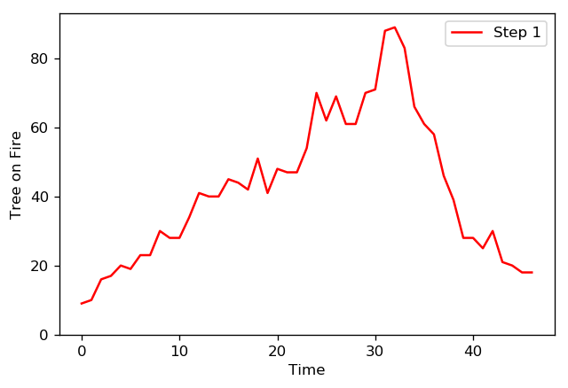

```python
fig, ax = plt.subplots(dpi=120)

c, = ax.plot(df["index"], df["Step 1"].values, "-", label = 'Step 1', color = 'red')

ax.set_ylim(bottom=0)
ax.set_xlabel("Time")
ax.set_ylabel("Tree on Fire")
ax.legend()
plt.show()
```

##### With this final graph we see a trend similar to the one from the previous graph. THe number of trees on fire for one phase of tree burning grows at a steep linear slope until the time that the fire starts to burn out. After the amount of trees on fire peaks this number drastically declines and almost twice the rate of its previous growth. This could prove useful to fire fighters to give insight on when the best times to combat the fire may be.

### Citations

##### Dr. James Glasbrenner, via:

##### https://github.com/mason-fa18-cds-411-001/course-materials/blob/master/class_notes/forest_fire/forest_fire_notebook.ipynb

##### Insurance Information Institute, via:

##### https://www.iii.org/fact-statistic/facts-statistics-wildfires